# *Salmonella* outbreak case study (Part 1: Univariate and stratified analysis): R guide

Authors: Ranya Mulchandani and Alicia Barrasa Blanco (UK-FETP)

April 2021

## An outbreak of *Salmonella* Typhimurium in the UK

This case study describes the investigation of an outbreak of *Salmonella* Typhimurium in the UK which was identified through the analysis of whole genome sequencing in 2020. As part of the larger outbreak, a case-control was conducted to identify potential vehicle(s) of infection.

The information presented in this case study and the associated data files have been deliberately changed to facilitate the acquisition of the learning objectives.

This Rmd accompanies the full pre-course exercise word document and provides R help/hints for **Part one section 2** only.

### Learning outcomes

The key learning outcomes for this exercise are:

- Conduct descriptive and univariate analysis in a foodborne outbreak;
- Conduct stratified analysis to check for potential confounders/effect modifiers.

### Pre-requisites

The expectation of participants using this R guide is a basic understanding of R. These include:

- setting working directory
- installing and loading packages
- reading in a dataset
- browsing your dataset
- basic data management and analysis
- familiarity with tidyverse packages

### This guide uses the “tidyverse way”

This guide primarily uses code from the tidyverse packages (dplyr, ggplot2, readr) rather than base R. A quick reminder of the main verbs used in the dplyr package:

- select() select variables by name
- filter() return rows with matching conditions
- mutate() add new variables
- summarise() reduce multiple values down to a single value
- group_by() group by one or more variables

## Setting up R Studio - installing and loading packages

The following code chunk will outline which packages will be used in this case study.

As always, there are multiple packages available that can do the same/similar analysis - the packages chosen in this case study are those familiar to the authors but are just one of multiple options available. When working through this case study, if you have alternative and/or easier approaches to conduct the same analysis, then please feel free to contribute to the continual improvement of this case study code by contacting one of the contributers listed above.

```r
# load packages

library(dplyr) # data manipulation
library(readr) # read_csv function
library(Hmisc) # describing data
library(ggplot2) # graphically displaying data
library(statar) # basic tabulations
library(EpiFunc) # basic tabulations, epicurves and age-sex pyramids
library(EpiStats) # univariate analysis
library(broom) # tidy function for model outputs
library(epiDisplay) # for stratified analysis
library(magrittr) # for the %$% operator

# Alternatively you can load the required packages using the following code:

# required_packages <- c("dplyr", "readr", "Hmisc", "ggplot2", "statar", "EpiFunc", "EpiStats", "broom", "epiDisplay")

# for (i in seq(along = required_packages))
#  library(required_packages[i], character.only = TRUE)

# If you do not have any of the packages listed above, first use install.packages(),
# followed by a return to library(). All packages should be available via CRAN.
# The only exception to this is the EpiFunc package (written by former-FETP Daniel Gardiner).
# To download the EpiFunc package, use the following code:

# install.packages("httr")
# httr::set_config(httr::config(ssl_verifypeer =0L))
# devtools::install_github("DanielGardiner/EpiFunc")

# read in dataset
data <- read_csv("salm_v1.4.csv")
```

# Descriptive and univariate analysis

## Help Question 5: What are the main characteristics of the study population?

## Understanding your data

This section will focus on exploring your dataset - looking at the overall structure, the key variables it contains, the variable types, number of observations, any missing values etc.

```r
# Explore the variables included in the dataset

names(data) # provides list of variable names
```

```
##  [1] "case"           "gender"         "age"            "grp_takeaway"
##  [5] "grp_chicken"    "grp_nutseed"    "grp_vegetables" "grp_fruit"
##  [9] "grp_cereal"     "grp_meatfish"   "frozenchick"    "filletchick"
## [13] "cabbage"        "carrot"         "macadamia"      "brazil"
## [17] "hazelnut"       "cashew"         "pecan"          "peanut"
## [21] "pistachio"      "nut_bar_a"      "nut_bar_b"      "id"
```

```r
glimpse(data) # view structure of your dataset
```

```
## Rows: 139
## Columns: 24
## $ case           <dbl> 1, 1, 1, 0, 0, 0, 0, 0, 0, 0, 1, 0, 0, 0, 0, 0, 0, 0...
## $ gender         <dbl> 1, 1, 0, 1, 0, 0, 1, 0, 1, 0, 0, 1, 1, 1, 0, 0, 1, 1...
## $ age            <dbl> 5, 15, 15, 20, 21, 21, 22, 25, 27, 27, 28, 29, 30, 3...
## $ grp_takeaway   <dbl> 1, 1, 0, 1, 1, 1, 0, 1, 1, 0, 0, 0, 1, 0, 0, 1, 0, 0...
## $ grp_chicken    <dbl> 0, 1, 1, 1, 1, 1, 1, 0, 1, 1, 1, 0, 0, 1, 0, 1, 1, 1...
## $ grp_nutseed    <dbl> 1, 1, 0, 0, 0, 1, 0, 0, 1, 0, 1, 1, 1, 0, 1, 1, 0, 0...
## $ grp_vegetables <dbl> 1, 1, 1, 1, 1, 1, 1, 1, 1, 1, 1, 1, 0, 1, 1, 0, 1, 1...
## $ grp_fruit      <dbl> 1, 1, 1, 1, 1, 1, 1, 1, 1, 0, 1, 1, 1, 1, 1, 0, 1, 1...
## $ grp_cereal     <dbl> 1, 1, 1, 1, 1, 0, 1, 1, 1, 0, 1, 1, 1, 0, 1, 1, 1, 1...
## $ grp_meatfish   <dbl> 1, 1, 1, 1, 1, 1, 1, 0, 1, 0, 1, 1, 0, 1, 1, 0, 1, 1...
## $ frozenchick    <dbl> 0, 1, 1, 1, 1, 1, 0, 0, 1, 1, 1, 0, 0, 1, 0, 0, 0, 1...
## $ filletchick    <dbl> 0, 0, 1, 0, 1, 0, 0, 0, 0, 0, 1, 0, 0, 0, 0, 0, 1, 0...
## $ cabbage        <dbl> 0, 1, 0, 0, 0, 0, 0, 0, 0, 0, 0, 0, 0, 0, 0, 0, 0, 0...
## $ carrot         <dbl> 1, 1, 1, 0, 0, 0, 0, 0, 0, 1, 1, 1, 0, 0, 0, 0, 0, 0...
## $ macadamia      <dbl> 0, 1, 0, 0, 0, 0, 0, 0, 0, 0, 0, 0, 0, 0, 0, 0, 0, 0...
## $ brazil         <dbl> 0, 1, 0, 0, 0, 0, 0, 0, 0, 0, 1, 1, 0, 0, 0, 0, 0, 0...
## $ hazelnut       <dbl> 0, 1, 0, 0, 0, 0, 0, 0, 1, 0, 0, 1, 0, 0, 0, 0, 0, 0...
## $ cashew         <dbl> 0, 1, 0, 0, 0, 1, 0, 0, 0, 0, 1, 1, 0, 0, 0, 1, 0, 0...
## $ pecan          <dbl> 0, 1, 0, 0, 0, 0, 0, 0, 0, 0, 0, 0, 0, 0, 0, 0, 0, 0...
## $ peanut         <dbl> 1, 1, 0, 0, 0, 0, 0, 0, 0, 0, 1, 0, 0, 0, 1, 1, 0, 0...
## $ pistachio      <dbl> 0, 0, 0, 0, 0, 0, 0, 0, 0, 0, 1, 0, 0, 0, 0, 0, 0, 0...
## $ nut_bar_a      <dbl> 1, 1, 0, 0, 0, 0, 0, 0, 0, 0, 0, 0, 0, 0, 0, 0, 0, 0...
## $ nut_bar_b      <dbl> 0, 1, 0, 0, 0, 0, 0, 0, 0, 0, 0, 0, 0, 0, 0, 0, 0, 0...
## $ id             <dbl> 22, 2, 16, 82, 27, 28, 83, 29, 84, 30, 1, 85, 86, 87...
```

```r
# provides preview of first 6 rows of dataset
# head(data)

# provides no. of observations, missing values
# Hmisc::describe(data)

# how many cases and controls are in the dataset
data %>%
  group_by(case) %>%
  summarise(n = n())
```

```
## # A tibble: 2 x 2
##    case     n
##   <dbl> <int>
## 1     0   113
## 2     1    26
```

## Managing your data

This section will focus on creating new variables required for the analysis - primarily a variable for age group, to allow for age-sex pyramids

```r
# Create age_group variable (useful when creating age/sex pyramids using EpiFunc)
data <- data %>%
  mutate(agegrp = cut(age, breaks=c(0,35,45,55,65,Inf)))

data <- data.frame(data)
```

## Describing your data

This section will focus on summarising key aspects of your dataset - for example looking at demographics

```r
# Summarise age in cases and controls
data %>%
  group_by(case) %>%
  filter(!is.na(age)) %>% #alternatively you could use the na.rm argument
  summarise(n = n(),
            median = median(age), mean = mean(age),
            min = min(age), max = max(age)) %>%
  ungroup() # good practice to ungroup your data
```

```
## # A tibble: 2 x 6
##    case     n median  mean   min   max
##   <dbl> <int>  <dbl> <dbl> <dbl> <dbl>
## 1     0   113     52  49.7    20    77
## 2     1    23     57  53.0     5    76
```

```r
# explore gender (StataR package)
data %>% tab(gender)
```

```
##
##   gender ¦    Freq.  Percent     Cum.
## ---------+----------------------------
##        0 ¦       71    51.08    51.08
##        1 ¦       68    48.92   100.00
```

```r
# try stratifying by case status
data %>% tab(case, gender) # you can see this package isn't so great for 2by2 tables
```

```
##
##     case ¦   gender ¦    Freq.  Percent     Cum.
## ---------+----------+----------------------------
##        0 ¦        0 ¦       56    40.29    40.29
##        0 ¦        1 ¦       57    41.01    81.29
## ---------+----------+----------------------------
##        1 ¦        0 ¦       15    10.79    92.09
##        1 ¦        1 ¦       11     7.91   100.00
```

```r
# let's use EpiDisplay package instead - gives a nicer 2by2 table, and ORs!

# to get percentages
data %$% tabpct(case, gender, graph = F) # don't worry about this slightly different pipe (magrittr package)
```

```
##
## Original table
##        gender
## case       0    1  Total
##   0       56   57    113
##   1       15   11     26
##   Total   71   68    139
##
## Row percent
##     gender
## case       0       1  Total
##    0      56      57    113
##       (49.6)  (50.4)  (100)
##    1      15      11     26
##       (57.7)  (42.3)  (100)
##
## Column percent
##        gender
## case      0       %   1       %
##   0      56  (78.9)  57  (83.8)
##   1      15  (21.1)  11  (16.2)
##   Total  71   (100)  68   (100)
```

```r
# to get ORs
data %$% cc(case, gender, graph = F)
```

```
##
##        gender
## case      0   1 Total
##   0      56  57   113
##   1      15  11    26
##   Total  71  68   139
##
## OR =  0.72
## 95% CI =  0.3, 1.7
## Chi-squared = 0.56, 1 d.f., P value = 0.454
## Fisher's exact test (2-sided) P value = 0.518
```

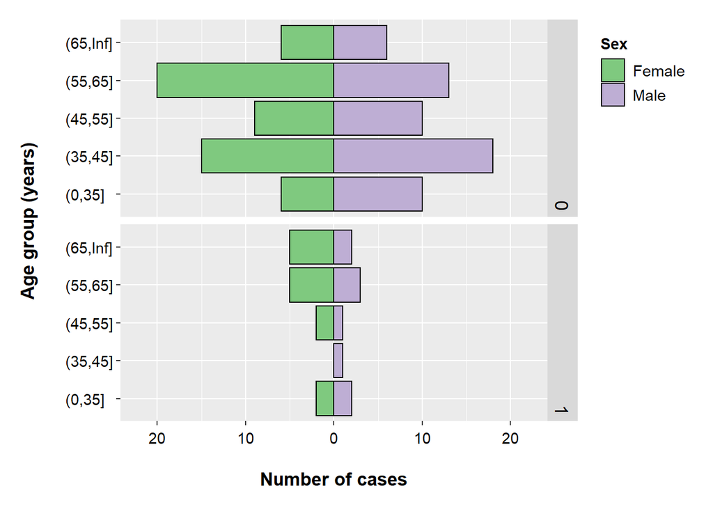

```r
# age-sex pyramid, split by whether case or control (EpiFunc package)
EpiFunc::age_sex_pyramid(data %>%
                           mutate(gender2 = if_else(gender == 0, "Female", "Male")),
                         age.grp.col = "agegrp", sex.col = "gender2", split.by = "case")
```

```r
# alternatively you can create age-sex pyamids directly using ggplot2

# ggplot(data, aes(x=agegrp, fill=gender2)) +
#   geom_bar(data=subset(data, gender2=="Female"),
#            color="white", width=1) +
#   geom_bar(data=subset(data, gender2=="Male"),
#            aes(y=..count..*(-1)),
#            color="white", width=1) +
#   theme_minimal() +
#   xlab("Age group") +
#   scale_y_continuous(breaks=seq(-20,20,1),
#                      labels=abs(seq(-20,20,1))) +
#   scale_x_discrete(limits=levels(data$agegrp)) +
#   geom_hline(yintercept=0) +
#   coord_flip() +
#   theme(panel.grid.minor=element_blank(), panel.grid.major=element_blank(), legend.title=element_blank())
```

## Help Question 6: What are the food-specific attack rates for the food group variables? What is the appropriate measure of association in this study?

## Exploring food-specific attack rates for food groups

This section will look at the attack rates and odd ratios for the food group exposure variables.

```r
# 2by2 table e.g. for takeaway by case status (EpiDisplay package)
data %$% cc(case, grp_takeaway, graph = F)
```

```
##
##        grp_takeaway
## case      0   1 Total
##   0      74  35   109
##   1      17   9    26
##   Total  91  44   135
##
## OR =  1.12
## 95% CI =  0.45, 2.76
## Chi-squared = 0.06, 1 d.f., P value = 0.807
## Fisher's exact test (2-sided) P value = 0.819
```

```r
# Univariable analysis (EpiStats package)
EpiStats::CCTable(data, "case",
                  exposure = c("grp_takeaway", "grp_chicken", "grp_nutseed", "grp_vegetables",
                               "grp_fruit", "grp_cereal", "grp_meatfish"), exact=TRUE) %>%
#note - do not include kable() when running directly in console (for Rmd visualisation purposes)
  knitr::kable()
```

|  | Tot.Cases | Exposed | % | Tot.Ctrls | Exposed | % | OR | CI ll | CI ul | p(Fisher) |
| --- | --- | --- | --- | --- | --- | --- | --- | --- | --- | --- |
| grp_nutseed | 26 | 23 | 88.46 | 113 | 56 | 49.56 | 7.80 | 2.15 | 42.34 | 0.000 |
| grp_cereal | 26 | 26 | 100.00 | 113 | 86 | 76.11 | Inf | 1.88 | Inf | 0.002 |
| grp_meatfish | 26 | 26 | 100.00 | 113 | 103 | 91.15 | Inf | 0.52 | Inf | 0.208 |
| grp_vegetables | 26 | 26 | 100.00 | 113 | 107 | 94.69 | Inf | 0.27 | Inf | 0.594 |
| grp_fruit | 26 | 26 | 100.00 | 113 | 107 | 94.69 | Inf | 0.27 | Inf | 0.594 |
| grp_chicken | 26 | 18 | 69.23 | 113 | 83 | 73.45 | 0.81 | 0.30 | 2.40 | 0.635 |
| grp_takeaway | 26 | 9 | 34.62 | 109 | 35 | 32.11 | 1.12 | 0.40 | 2.97 | 0.819 |

```r
# by default the variables have been ordered by p-value
```

## Help Question 7: What would your next steps of analysis be?

## Exploring food-specific attack rates for individual food items

This section will look at the attack rates and odds ratios of the individual food item exposure variables.

```r
EpiStats::CCTable(data, "case",
                  exposure = c("frozenchick", "filletchick", "cabbage", "carrot",
                               "macadamia", "brazil",
                               "hazelnut", "cashew", "pecan", "peanut",
                               "pistachio", "nut_bar_a", "nut_bar_b"), exact=TRUE) %>%
 #note - do not include kable() when running directly in console (for Rmd visualisation purposes)
  knitr::kable()
```

|  | Tot.Cases | Exposed | % | Tot.Ctrls | Exposed | % | OR | CI ll | CI ul | p(Fisher) |
| --- | --- | --- | --- | --- | --- | --- | --- | --- | --- | --- |
| cabbage | 26 | 10 | 38.46 | 113 | 8 | 7.08 | 8.20 | 2.45 | 27.39 | 0.000 |
| carrot | 26 | 17 | 65.38 | 113 | 20 | 17.70 | 8.78 | 3.12 | 25.40 | 0.000 |
| brazil | 26 | 14 | 53.85 | 113 | 11 | 9.73 | 10.82 | 3.58 | 32.63 | 0.000 |
| nut_bar_a | 26 | 11 | 42.31 | 113 | 4 | 3.54 | 19.98 | 4.94 | 93.80 | 0.000 |
| hazelnut | 26 | 11 | 42.31 | 113 | 13 | 11.50 | 5.64 | 1.89 | 16.44 | 0.001 |
| nut_bar_b | 26 | 5 | 19.23 | 113 | 2 | 1.77 | 13.21 | 1.95 | 143.46 | 0.003 |
| cashew | 26 | 12 | 46.15 | 113 | 23 | 20.35 | 3.35 | 1.23 | 8.97 | 0.011 |
| pecan | 26 | 5 | 19.23 | 113 | 6 | 5.31 | 4.25 | 0.92 | 18.22 | 0.033 |
| peanut | 26 | 13 | 50.00 | 113 | 31 | 27.43 | 2.65 | 1.00 | 6.93 | 0.035 |
| macadamia | 26 | 3 | 11.54 | 113 | 3 | 2.65 | 4.78 | 0.59 | 37.43 | 0.079 |
| pistachio | 26 | 4 | 15.38 | 113 | 7 | 6.19 | 2.75 | 0.54 | 11.87 | 0.125 |
| frozenchick | 26 | 14 | 53.85 | 113 | 54 | 47.79 | 1.27 | 0.50 | 3.30 | 0.665 |
| filletchick | 26 | 6 | 23.08 | 113 | 27 | 23.89 | 0.96 | 0.28 | 2.81 | 1.000 |

## Help Question 8: What is your interpretation of finding from the univariate analysis?

–

## Help Question 9: How would you further assess potential vehicle(s) of infection?

## Statified analysis

This section will look at statified analysis of Nut Bar A by other food items

```r
# stratified analysis (EpiDisplay package)

# stratify by cabbage
epiDisplay::mhor(data$case, data$cabbage, data$nut_bar_a, graph = F) # results indicate potential confounder
```

```
##
## Stratified analysis by  Var3
##                OR lower lim. upper lim. P value
## Var3 0       5.19      0.961       24.6 0.02801
## Var3 1       3.31      0.191      219.5 0.56923
## M-H combined 4.71      1.347       16.4 0.00946
##
## M-H Chi2(1) = 6.73 , P value = 0.009
## Homogeneity test, chi-squared 1 d.f. = 0.09 , P value = 0.762
```

```r
# stratify by cashews
epiDisplay::mhor(data$case, data$cashew, data$nut_bar_a, graph = F) # nothing
```

```
##
## Stratified analysis by  Var3
##                OR lower lim. upper lim. P value
## Var3 0       3.42      0.946      12.15  0.0448
## Var3 1       2.36      0.134     156.89  0.6044
## M-H combined 3.25      1.156       9.13  0.0209
##
## M-H Chi2(1) = 5.34 , P value = 0.021
## Homogeneity test, chi-squared 1 d.f. = 0.07 , P value = 0.794
```

```r
# stratify by brazil nuts
epiDisplay::mhor(data$case, data$brazil, data$nut_bar_a, graph = F) # results indicate potential effect modifier
```

```
##
## Stratified analysis by  Var3
##                  OR lower lim. upper lim.  P value
## Var3 0       15.954     4.0713       69.2 1.10e-05
## Var3 1        0.844     0.0449       15.8 1.00e+00
## M-H combined  6.414     2.1467       19.2 1.79e-05
##
## M-H Chi2(1) = 18.4 , P value = 0
## Homogeneity test, chi-squared 1 d.f. = 5.09 , P value = 0.024
```

```r
# now do the same for the rest of the variables...
```

Results from univariate and stratified analysis will be reviewed in the MVA module (in part two of this case study)…..